# Jo-CreatorLoyaltyGameUsage-2024-arXiv.pdf

Converted from PDF `Jo-CreatorLoyaltyGameUsage-2024-arXiv.pdf` · 51 pages · anchors: page `#pN`, block `#pN-bK`

Page 1

Can Loyalty to Creators Dilute Loyalty to Promoted Products?

Examining the Heterogeneous Effects of Live-Streamed Content on Video Game Usage

Wooyong Jo, Mike Lewis, Yanwen Wang

#### *Abstract*

Social media platforms have led to online consumption communities, or fandoms, that involve complex networks of ancillary creators and consumers focused on some core product or intellectual property. For example, video game communities include networks of players and content creators centered around a specific video game. These networks are complex in that video game publishers often sponsor creators, but creators and publishers may have divergent incentives. Specifically, creators can potentially benefit from content that builds their own following at the expense of the core game. Our research investigates the relationship between consuming live-streamed content and engagement with a specific video game. We examine the causal effect of viewing live-streamed content on subsequent gameplay for a specific game, using an unexpected service interruption of the livestreaming platform and time zone differences among users. We find live-streamed content significantly increases gameplay as a 10% increase in livestreamed viewing minutes results in a 3.08% increase in gameplay minutes. We also explore how this effect varies by user loyalty to different types of streamer channels (firm-owned, mega, and micro). The positive effects of live-streamed content are greatest for micro-streamers and smallest for mega-streamers. These findings are salient for firms allocating sponsorship resources.

Keywords: Livestreaming; Creator economy; Influencer marketing; Natural experiment; Video game

analytics

Wooyong Jo (wooyong@purdue.edu) is Assistant Professor of Marketing at Daniels School of Business at Purdue University, Mike Lewis (mike.lewis@emory.edu) is Professor of Marketing at the Goizueta School of Business, Emory University, Yanwen Wang (yanwen.wang@sauder.ubc.ca) is Associate Professor of Marketing at the Sauder School of Business, University of British Columbia.

Page 2

1

#### **1. Introduction**

Livestreaming through online platforms like Twitch, YouTube, Facebook, or TikTok, has become a

popular type of entertainment. For example, as of 2024, the livestreaming platform Twitch hosts

approximately 240 million unique visitors every month (Dean 2024), which is roughly ten times the

number of Netflix’s monthly active users (Spangler 2024). Given the audience size, marketers have

rapidly recognized the potential of livestreaming creators and other social media personalities (a.k.a.

influencers). Marketing spending on creators on streaming and social media platforms is estimated to be

about $24 billion in 2024, compared to just $1.7 billion in 2016 (Influencer Marketing Hub 2021). Survey

data suggests that creators can influence consumer behavior, with 84% of consumers having tried a

product recommended by creators or social media influencers (Inmar Intelligence 2021).

Livestreams vary in subject content and can include live podcasts, musical performances, and talk

shows. Video games are an especially popular source of content, and video game streamers play a critical

role in the gaming industry. Video game streaming, where an expert or entertaining player live broadcasts

his or her gameplay, is an important part of video game and esports communities as it increases interest in

gaming and creates connections within the gamer and fandom communities. According to statistics from

the 100 top categories on Twitch (SullyGnome 2024), in January 2024, consumers watched over 99

billion hours of live-streamed content on Twitch, with the video game category accounting for about 80%

of these hours.<sup>1</sup> As livestreaming has grown in popularity, star creators have emerged. Tyler Blevins, or

Ninja, has amassed over 19 million followers on Twitch (Muller 2024), and in 2019, Microsoft paid him

approximately $30 million to move to their streaming platform, Mixer (Brown 2020).

Livestreams in the video game industry are noteworthy in several respects. For instance, for

major games, many creators may focus on a specific game and may play an essential role in their specific

gaming community by providing entertainment, expertise, and excitement related to a particular game

(Huang and Morozov 2024, Jo and Lewis 2024, Li et al. 2024). There is also variety within the population

1 99 billion hours of streamed content viewed on Twitch in a single month is comparable to the total view time recorded on Netflix (94 billion hours) over six months during the same year (Netflix 2024).

Page 3

2

of creators. Some creators have substantial audience sizes, while others present to small audiences (Tian

et al. 2024). Audience size may be important in livestreaming because streaming often involves

interaction with the gaming community (Lu et al. 2021). Game publishers also operate “official”

streaming channels to provide curated editorial content to the game community (Jo and Lewis 2024).

However, significant questions about creators’ effectiveness in influencing video game

consumers remain unanswered. The questions are primarily related to the function and impact of creators

within a gaming community. Creators' content might be inspirational or educational, stimulating more

follow-up gameplays, and increasing fandom for the game. However, since creators provide

entertainment, they can potentially develop their own fan bases and compete with the game for

consumers’ attention. In addition to whether streamers provide complements to or substitutes for the

game, there are questions about the effects of streamer-player relationships. When creators acquire their

own loyal fans, what happens to influence and does influence varies across types of creators. A creator

with tens of thousands of viewers cannot provide the same level of interactivity as a creator with a

hundred viewers (Lu et al. 2021). The creator with a smaller, more interactive community might have

stronger relationships and exercise more influence. However, a creator with a massive audience might be

viewed as more credible (Leung et al. 2022). Furthermore, a publisher-owned channel might be more

credible, but it might be viewed skeptically because of its affiliation with the game publisher. The effects

of influencer type have largely been unexplored.

Our research examines creator influence within a specific gaming community. The game is one of

the largest in the MOBA (Multiplayer Online Battle Arena) category and our data includes information on

user engagement with both the game and live streamers. We investigate the effect of viewing creators'

live-streamed content on subsequent gameplay, leveraging a natural experiment. The exogenous shock we

rely on is an unexpected outage of the streaming platform that did not affect the video game. The key to

this natural experiment is that the outage differentially impacted users based on their local time zones.

Our research strategy focuses on developing a multilevel understanding of the role of creators. At

the top level, we address the overarching question: Is live-streamed content a complement to or substitute

Page 4

3

for the original source material (the game) within a gaming community? This is an important question in

the video game industry because most creators’ content consists of shared screens of their gameplay,

which can directly fulfill users’ needs and interests in a specific video game (substitution effect).

However, this content can deepen viewers' understanding of the focal game and potentially nurture and

elevate their interest in purchasing or playing it (complementary effect). We also explore how creator

content and gameplay are co-consumed. Using individual-level data, we examine whether live-streamed

content tends to be consumed concurrently with gameplay or in sequence. The final level of analysis

considers streamer-player connections, as we consider how creator influence varies based on streamer-fan

relationship metrics and audience size.

Our analysis suggests that watching live-streamed content has a positive effect on users’

gameplay. We identify these effects with a control function approach using instruments that leverage an

outage of Twitch.tv, the leading live-streaming platform, which affected some players during peak

gaming hours and others during non-peak hours. The results indicate that livestreaming is a beneficial part

of the gaming community, as the content drives incremental play rather than acting as a substitute. In

terms of how the two types of content (game and streamed content) are co-consumed, we find empirical

evidence that sequential rather than concurrent consumption is the more prevalent form of co-

consumption. We also find that the nature of fans' relationships with streamers significantly impacts the

effects of viewing live-streamed content. Specifically, when users are loyal to mega streamers, the

positive effects of viewing live-streamed content decrease, whereas these effects increase when users are

loyal to micro streamers. In addition, loyalty to the firm-owned channel decreases the positive effect of

live-streamed content, but the reduction is less pronounced than the effect of loyalty to mega streamers.

Our research primarily contributes to the literature on the creator economy and influencer

marketing. Our primary contributions come from our expansion of the research context. While previous

studies have focused on game publishers and streamers (Huang and Morozov 2024, Jo and Lewis 2024,

Li et al. 2024), we broaden the research scope by considering the fandom community component of the

ecosystem and examining the role of creator-fan relationships. What primarily differentiates our work

Page 5

4

from other studies in the literature is that we focus on *user*-level heterogeneity in response to creators'

content, whereas prior research has predominantly examined *creator*-level heterogeneity (Li et al. 2024,

Tian et al. 2024) or *firm*-focused insights (Huang and Morozov 2024, Jo and Lewis 2024). Our more

granular user-focused exploration is possible because we possess data on individual-level gaming linked

to creator content, whereas other studies have relied on publicly available data scraped at the video game

level (Huang and Morozov 2024, Li et al. 2024).

#### **2. Category Structure and Intended Contribution**

The creator economy, which encompasses the monetization of content by creators across various digital

platforms, has emerged as a significant element in modern marketing and sponsorship strategies

(Bhargava 2022, Lu et al. 2021). This section discusses the value creation process that underlies the

livestreaming creator economy, summarizes related research, and outlines our intended contributions.

2.1. Creator Economy Value Creation

At a high level, our overarching goal is to develop insights into the interdependence between content

creators, the firms that create the central source material, and consumers. Our ultimate contributions are

related to how consumers’ heterogeneous preferences and behaviors combined with firm and creator

incentives create complex consumption communities. We begin with a discussion of category structure

that highlights the interplay between the different entities and motivates our empirical strategy.

The creator economy, especially in entertainment categories like video games, often involves a

fundamentally different value creation process than the standard value chain. In the standard value chain,

value creation is conceptualized as a linear process where steps in the chain, ranging from material

sourcing to product recycling, create value for consumers. In the livestreaming creator economy,

consumers often gain value through participation in a distributed fandom community rather than through

a single product. Figure 1 visually depicts the key entities within a consumption or fandom community

and lists relevant studies. In this diagram, the basis for the fandom community is some core content and a

body of ancillary content. In the case of video games, consumers are members of fandoms who gain value

Page 6

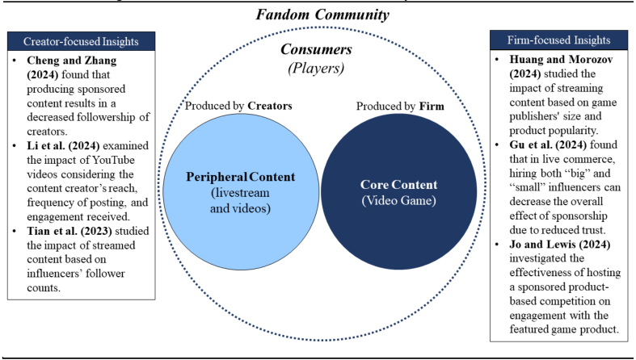

NOTE: figure/graphic rendered as an image from the PDF; its content is not machine-readable text. Caption (if any) follows as the next block.

5

from a “core” video game and “peripheral” products such as streamed content related to the game, esports

competitions, or conventions that feature activities like cosplay (costume play).

Figure 1: Creator’s Role in the Fandom Community and Related Studies

Note: Colors are available online.

The preceding description of a fandom community involving a core element, supplementary

content created, and consumers is an important conceptualization for our research because it highlights

the interrelationship between independent organizations marketing to the same group of fans. We use the

term fans because consumers of the core content are explicitly focused on some core product with cultural

meaning, such as a video game or entertainment franchise (Lewis 2024). In our context, the core product

(the dark blue circle in Figure 1) is the specific video game, and the firm is the game publisher. The value

directly associated with the core product is straightforward. An exciting or entertaining video game

provides direct utility to players. The second element of the diagram is the content produced by creators

(the light blue circle in Figure 1). These creators develop original programming based on the core

product. These creators add value to the fandom ecosystem through entertaining, educational, or

otherwise engaging content related to the core product. The third element of the diagram is the consumers

or players. The consumers comprise the community built around the core product and associated content.

Page 7

6

The consumers (players) are also part of the value-creation process. Players frequently compete with and

against each other, and livestreaming features live chats that allow players to interact with content

creators and other players.

A possible complexity is that since the core product and the peripheral content are not

coordinated by a single firm, there are potential conflicts. The core product maker and the content creators

share some objectives, as both benefit from a stronger fandom or consumption community. However,

content creators are also potential competitors, as they exist in a competitive space and try to maximize

their followings and engagement. Potentially, ancillary content may become a competitor to the core

product if consumers choose to watch creator content rather than play the core product. Further

complicating the situation is that content creators can be valuable marketing partners for the core firm.

When content creators may specialize in categories like gaming or fashion, they can develop specialized

audiences that are the primary targets for game publishers or fashion designers. Core firms can

conceptually benefit by sponsoring creators to promote their products or services (Gu et al. 2024, Tian et

al. 2024). Content creators may also be especially effective influencers as their independence allows them

to build trust, engagement, and loyalty among their followers (Leung et al. 2022).

Understanding the potential competition and opportunities for cooperation between content

creators and core product consumption requires an understanding of the end consumers or fans. In our

context, the users are fans of a video game who both play the game and watch live-streamed content

about the game. Users play an important role because they ultimately determine the success of both the

content creators and the sponsoring firms. Their engagement with the created content drives visibility,

reach, and influence, while their purchasing decisions directly impact the return on investment for

sponsoring brands. Understanding users' preferences and behaviors is crucial for both creators and firms

to tailor their content and marketing strategies effectively.

The discussion of the interrelationships between creators, firms, and consumers highlights two

critical issues. First, creators and firms have incentives to cooperate and compete. Understanding whether

and how ancillary content is a compliment or substitute is critical to understanding the creator economy.

Page 8

7

Second, conceptualizing a creator economy as a consumption or fandom community is vital because it

highlights the potential role of relationships between consumers and independent creators. These

relationships are potentially a foundational element of these communities, and the impact of consumer-

creator relationships may significantly impact source material firms’ sponsorship strategies.

2.2. Literature

Previous research in marketing on the creator economy has primarily focused on the first two elements of

Figure 1: the *firms* that produce the core products and the *creators* who produce ancillary content.

Creator-focused research has sought to identify which creators are more or less effective in promoting

products (Cheng and Zhang 2024, Li et al. 2024, Tian et al. 2024) while firm-focused research has

investigated whether and how sponsoring firms can benefit from sponsoring creators (Feng et al. 2024,

Gu et al. 2024, Huang and Morozov 2024, Jo and Lewis 2024). The boxes on the far left and right of

Figure 1 summarize the findings from creator economy research.

In terms of *creator*-focused insights (left side of Figure 1), Tian et al. (2024) examined the

follower elasticity of impressions on a livestreaming platform and found that although the effect of

followership is always positive, it varies non-linearly, allowing for the identification of the most effective

influencers to sponsor. Li et al. (2024) analyzed the effects of total YouTube video counts on overall

game usage using aggregate data. Their findings indicate that working with YouTube creators who

repeatedly post content about a specific game may not effectively generate positive spillover. Cheng and

Zhang (2024) empirically confirmed that posting sponsored videos results in decreased followership, but

this reputation-burning effect dissipates if the sponsored content has a greater fit with the organic content

produced by the creators.

Research on how *firms* can employ sponsorships has focused on different aspects (right side of

Figure 1). For instance, using data collected from Twitch and Steam, Huang and Morozov (2024)

estimated the impact of “viewership stock” on the streaming platform at the video game title level on

active users on Steam. While they found a positive impact of the availability of live-streamed content on

Page 9

8

usage, they also emphasized that sponsorship of creators requires careful assessment, as it is only

profitable for some games and not in general. In addition, Gu et al. (2024) found that in live commerce,

hiring both “big” and “small” influencers can decrease the overall effectiveness of sponsorship due to

reduced trust. This suggests that firms should be cautious when designing the influencer mix for their

sponsorship strategies. Finally, Jo and Lewis (2024) examined the case of firms taking on the role of

content creators by hosting live-streamed sponsored product-based competitions (SPC). They found that

watching SPCs generally increases customer engagement, including both product usage and spending.

This increase is driven by knowledge transfer that occurs when promoted products are expertly

demonstrated.

2.3. Contributions

The review of related papers in the literature reveals several research opportunities. First, research efforts

have primarily focused on generating insights related to *creators'* and *firms'* decisions. While firm and

creator-level decisions are critical to understanding creator economies, the literature has paid insufficient

attention to the behaviors of the communities of consumers that underlie these fandom ecosystems.

Research on *users’* decisions and heterogeneity is needed as the community of consumers is the source of

engagement and revenues. Second, since creators usually aim to build their own brands in the platform on

which they distribute content, the creators put efforts into growing their individual brands and loyal fans.

The importance of brand and follower building to creators has been neglected due to a lack of

individual consumer data. Previous research has relied on aggregate or game level results rather than

individual gamer histories. In the context of the value-creation system focused on a fandom community

(Figure 1), the creators’ loyalty-building goals can become problematic when streamers promote

entertainment products, such as video games, as the content created by the streamer may directly compete

with the core product. This is especially problematic when the firm sponsors independent creators. In

other words, the influence of endorsements by creators should be carefully assessed by examining

Page 10

9

whether loyalty to streamers truly translates into loyalty to the promoted products. Understanding the

impact of consumer-creator loyalty requires data on individuals’ choices of streamers.

In this study, we examine which types of users are more (or less) receptive to the influence of

created content on using promoted products. Specifically, we study the relationship between gamers

watching Twitch streamers and playing the focal video game. This approach allows us to investigate user

heterogeneity, rather than focusing on creators or firms (see Figure 1). In addition, the granular level of

data allows us to examine the process of how users consume both peripheral content (livestreaming) and

core material (video games). The use of aggregate-level data has limited previous researchers' ability to

investigate how creator content and source material are co-consumed (Huang and Morozov 2024, Li et al.

2024). Finally, we empirically investigate the heterogeneous effects of created content on product usage

based on users' loyalty to streamers. Loyalty and relationships are crucial in the creator economy, as users

often have favorite creators whom they follow and whose content they repeatedly consume. Our goal is to

determine whether and how loyalty to different types of streamers affects the usage of endorsed products.

This effort will also significantly extend the literature by assessing how user loyalty dynamics interact

with the convenience of engaging with streamers (popular vs. less popular) and vary depending on who

creates the content (independent creators or firms) to impact product usage.

#### **3. Data and Constructs**

Video games have evolved to have tremendous appeal as games consumers play and as entertainment,

such as livestreams and esports, for consumers to watch. Understanding the interplay of consumers'

decisions to watch or play over time is vital for game publishers. The data for our investigation includes

information on livestream viewing and gameplay. This section outlines these datasets and details the

operational definitions of our key variables.

3.1. Data

A major U.S. game publisher provided data on livestreaming content viewing and gameplay. The firm

supplied anonymized user-level data for both gameplay and livestreaming content viewed on Twitch.tv

Page 11

10

for their most successful video game title. This game falls into the MOBA (Multiplayer Online Battle

Arena) genre, where players form two teams of five members and attempt to conquer the opposing team’s

base. The game publisher uses a freemium business model, meaning no upfront fee is required to play. It

has remained one of the top five most popular games in its genre globally since its release in the 2010s.

The sample of users was randomly drawn from nine distinct countries, proportional to each user

base. These nine countries were selected to enable the identification of the effect using time zone

differences (as discussed further in Section 4 and 5). The nine countries are also among the game's top 12

markets. In addition to the U.S. (UTC-4; U.S. Eastern time), eight countries in Europe were selected: the

U.K. (UTC+1), Spain (UTC+2), Germany (UTC+2), France (UTC+2), Poland (UTC+2), Romania

(UTC+3), Ukraine (UTC+3), and Türkiye (UTC+3). Table 1 provides descriptive statistics of our sample

by country.

Table 1: Samples by Country of Origin

[output not shown]

NOTE: table converted from PDF layout to HTML text; cell boundaries are reconstructed. See PDF if exact alignment matters.

Our data is a combination of game playing and live-streamed content viewing. The gameplay data

includes user identifiers, sign-up dates, countries of origin, and gameplay logs (i.e., timestamps of game

matches played). The livestream data includes viewing logs, which contain the same user identifiers, the

identifiers of the streamers watched by the users, timestamps of viewing (start and end), and the

identifiers of the video games being broadcast by the streamers. The data spans nine weeks, from July 18,

2017, to September 18, 2017. We use the first four weeks of data as a calibration period to compute user-

level characteristics (e.g., loyalty to streamers) and estimate the effect of streamed content viewing on

Page 12

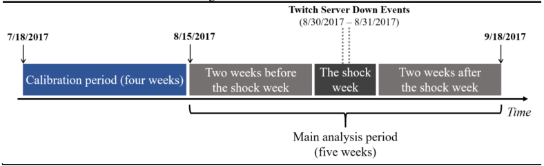

NOTE: figure/graphic rendered as an image from the PDF; its content is not machine-readable text. Caption (if any) follows as the next block.

11

subsequent gameplaying using the remaining five weeks. These five weeks coincide with the unexpected

server outage of Twitch.tv, which we describe in Section 4. Figure 2 shows the date ranges and time of

the exogenous shock.

Figure 2: Observation Period

Note: Color is available online. 3.2. Types of Live Streamers

One of our objectives is to understand the effect of watching different types of streamers on the

subsequent gameplay. We categorize streamers based on audience size and whether it is the official

channel. We conjecture that audience size impacts streamers’ ability to build loyal relationships and

credibility (Leung et al. 2022). In addition, “Official” status may impact the streamers’ perceived

neutrality as consumers may perceive the firm’s channel as a marketing tool. We categorize the 5,424

streamer accounts in our data by their popularity and whether the channel is independent.

We define streamers’ popularity based on the share of view minutes during the calibration period

(first four weeks of data). As noted by previous studies (Gu et al. 2024, Tian et al. 2024), viewership or

popularity distribution in livestreaming platforms is highly skewed and centered on a small number of

“mega” influencers. These mega streamers often sponsored due to their audience size and presumed

influence (Gu et al. 2024, Hughes et al. 2019). We first identify the 36 major streamer accounts, which

account for about 80% of viewing minutes related to the game during the calibration period. From this

group, we identify the firm-owned channel and 35 independent mega-streamers. We categorize the

remaining 5,388 streamers as micro-streamers. Figure 3 shows the distribution of viewership shares.

Page 13

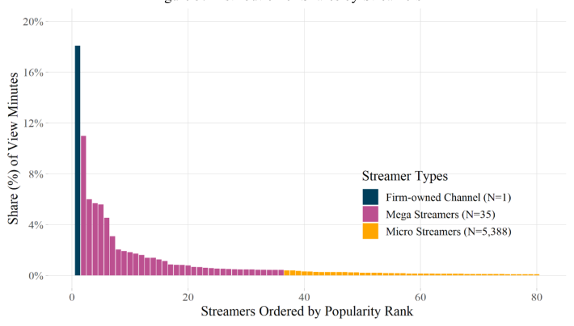

NOTE: figure/graphic rendered as an image from the PDF; its content is not machine-readable text. Caption (if any) follows as the next block.

12

Figure 3: Distribution of Shares by Streamers

Note: We plot the shares of the top 80 streamers for display. Our sample has 5,424 streamers.

Popularity may signal the performer’s potential for influence (Lu et al. 2021). First, popular

streamers host larger audiences on the streaming platform. More extensive reach suggests that these

streamers can provide greater exposure to a sponsor (Gu et al. 2024). In terms of consumer inferences, it

also seems likely that a mega streamer that draws 1,000 viewers would be viewed differently than a micro

streamer with an audience of 30. Since the streaming platform reveals the live audience size, these cues

might suggest source credibility to potential viewers (Leung et al. 2022).

Second, the differences in audience sizes across mega and micro streamers may impact the nature

and frequency of performer-viewer interactions and, ultimately, the level of interest in the promoted game

(Gu et al. 2024). Audience size places meaningful constraints on the ability of streamers to interact with

audience members (Ford et al. 2017, Gu et al. 2024, Lu et al. 2021). For example, Ford et al. (2017) found

that viewers' messages enjoy less time on the screen due to the larger volume of chats as the audience size

increases. The decrease in potential interaction with mega streamers may place a constraint on the

strength of the mega streamer-viewer relationship and, therefore, reduce influence. Using a field

experiment on a Chinese livestreaming platform, Lu et al. (2021) also found that viewers’ tipping

amounts to streamers increase as audience size increases. They suggested that this is because concerns

Page 14

13

about social image mainly affect viewers’ tipping behaviors. This finding also reveals something relevant

about audience-streamer interaction. As audiences become larger, viewers must tip more to attract the

streamer's attention or impress other audience members. The implication is that larger audiences reduce

interaction with streamers since the “cost” to interact increases (Lu et al. 2021).

Therefore, watching popular mega streamers may feel like being part of a large audience, with the

focus on the streamer's performance as a form of entertainment. In contrast, micro streamers may offer a

more intimate and relationship-focused viewing experience, emphasizing enjoying the game with close

friends. The closer interaction with viewers can help maintain attention on the game itself, as streamers

can even adjust their content to better fit the viewers' preferences and interests. As a result, viewers with

stronger loyalty to micro-streamers may be more inclined to play the games themselves after watching.

In addition to audience size, other streamer attributes may affect the performer’s ability to

influence viewers. For example, the relationship of the streamer channel to the promoted game may affect

influence. A firm-owned channel may be an especially credible source because it has access to inside

information about the game. Firm-owned channels may also be better funded and have better production

values. However, if viewers consider the channel a marketing tool, firm-owned channels may lack

credibility. Among the 36 largest streamer accounts in our sample, the most viewed channel (during the

calibration period) is the channel run by the game publisher. Therefore, we classify this account as a firm-

owned channel to distinguish it from independent large streamers. Table 2 provides viewership market

shares for the streamer types during the calibration period. The firm-owned channel has the largest market

share as a single channel, accounting for 18% of view minutes during the calibration period.

Table 2: Types of Streamers

[output not shown]

NOTE: table converted from PDF layout to HTML text; cell boundaries are reconstructed. See PDF if exact alignment matters.

1: Firm-owned account 1 18.07% 2: Mega-streamers 35 61.68% 3: Micro-streamers 5,388 20.25%

Page 15

[output not shown]

NOTE: table converted from PDF layout to HTML text; cell boundaries are reconstructed. See PDF if exact alignment matters.

14

3.3. Measuring User Loyalty to Streamers

A crucial feature of our dataset is that it allows us to track individual users' choices to view specific

streamers over an extended period. This feature offers a unique opportunity to assess individuals’

preferences for content produced by specific creators. Understanding this dynamic is important in

livestreaming and creator-based economies or platforms, as repeated engagement with a particular creator

can reveal the role of user-creator relationships in a product endorsement setting.

In our study, we define a user’s “loyalty” status to a particular streamer as a consistent and

repeated pattern of following and viewing content produced by streamers. We operationalize user loyalty

to a streamer by identifying users who watched the streamer at least *eight* separate times during the four-

week calibration period (equivalent to two unique views per week). To ensure robustness, we replicate the

entire analysis using both stricter (twelve views) and more relaxed (four views) definitions of loyalty.

Table 3 presents the viewing minutes of streamed content during the calibration period (Panel A)

and the ratio of viewing time for a specific type of streamer to the total viewing time for the same period

(Panel B). On average, users spend around 680 minutes viewing streamers they are not loyal to, compared

to about 922 minutes viewing streamers they are loyal to (eight or more separate views). However, in

Panel B, the ratio of time spent on non-loyal streamers to total viewing time is approximately 67%, while

Page 16

15

the time spent on loyal streamers accounts for the remaining 33%.

The discrepancy arises because the mean values of absolute viewing times reflect the average

minutes spent per user on loyal and non-loyal streamers, whereas the ratios in Panel B represent the total

proportion of viewing time across all users. While users spend more minutes on average with streamers

they are loyal to (922 minutes vs. 680 minutes), there are many more non-loyal streamers viewed, leading

to a higher overall share of viewing time (67%) for non-loyal streamers in the total aggregate measure.

Since our objective is to measure whether users spend more time on streamers they are loyal to at

an individual level, we use the ratios of time on types of streamers for follow-up analyses. Among the

33% of time spent on favorite streamers, users devote most of their time (24% of total viewing time) to

mega streamers, with the remaining time similarly distributed between firm-owned (4.2%) and micro

(5.1%) streamers. However, given that the firm-owned channel represents a single streaming account

while the micro category includes thousands, a significant number of users remain loyal to content created

by the firm-owned channel, consistently consuming its content.

The loyalty variables reveal individual preferences for types of creator content. At a high level,

some users may frequently switch between multiple streamer accounts without developing loyalty.

However, even when users become loyal to specific streamers, this loyalty may emerge differently—

some may repeatedly visit “big name” mega streamers or content created by a firm-owned channel that

features insider information and curated content for the game. Others may prefer streamers with small to

medium-sized followings who offer niche content. The impact of live-streamed content on promoted

video games may vary depending on the specific loyalty traits of each user. We do not make directional

predictions for each loyalty trait a priori; instead, we allow the data to reveal the empirical patterns.

#### **4. The Shock: Twitch Service Interruption**

We next introduce the exogenous shock that facilitates identification in our empirical analysis and the

causal interpretation of the results. Standard empirical challenges exist in estimating the effect of viewing

streamed content on game playing. Ideally, it would be possible to randomly assign users into two groups

Page 17

16

(treatment and control), restrict or limit the viewing of live-streamed content for the control group, and

then measure the difference in gameplay minutes between the two groups. However, such an experiment

is infeasible because livestreaming platforms and video game firms are often separate entities, and even if

they have close relationships, it is ethically and commercially problematic to restrict some users’

opportunity to watch live-streamed content. The empirical challenge is that both activities are highly

correlated with many unobservable factors, making causal inference challenging. For instance, a spike in

interest in a particular video game at a certain time of year may lead to increased viewing of that game's

live-streamed content and gameplay.

To address these empirical and practical challenges, we leverage an unexpected interruption of

Twitch.tv, which lasted approximately 10 hours from August 30 to 31, 2017. This disruption is useful for

identifying our effect of interest because it creates an exogenous variation in users' ability to view

streamed content without affecting their ability to play the focal video game. Although the event had a

global impact, we leverage the fact that the server outage occurred at different points in the day across the

globe. The outage occurred during the afternoon and evening hours in the U.S. (Eastern Time),

corresponding to late evening or past midnight in Europe. This geographic variation is crucial because

most game players tend to watch streamed content and play video games primarily during the afternoon

or evening. Therefore, we suspect that the event caused “greater” disruptions in livestreaming viewership

for users in the U.S. compared to those in Europe. Importantly, the video game servers remained

operational throughout this period, allowing us to attribute any observed effects to the Twitch disruption.

Starting around 3:00 PM on August 30, 2017 (U.S. Eastern Time), some users began

experiencing technical issues accessing the website. As the website failed to load properly for many users,

Twitch released its first announcement via its Twitch Support account on Twitter (now known as X) at

3:54 PM (U.S. Eastern Time), acknowledging the technical issue affecting page loading and stating that

their team was actively working on the problem. Unfortunately, the technical issue persisted for about ten

more hours, and it was resolved around 1:00 AM on August 31, 2017 (U.S. Eastern Time). In addition to

several announcements made by the Twitch Support Team on Twitter, there was a significant spike in

Page 18

17

Google Trends for “Twitch Down,” and media outlets reported that Twitch was unavailable from August

30 to 31, 2017 (Tylwalk 2017). We provide exhibits documenting the incident in Web Appendix A.

Table 4: Service Status of Twitch and Local Times in Countries on August 30 and 31, 2017

| Timezone | US Pacific | US Mountain | US Central | US Eastern | EU Western | EU Central | EU Eastern |
| --- | --- | --- | --- | --- | --- | --- | --- |
| UTCtime | UTC 7h – | UTC 6h – | UTC 5h – | UTC 4h – | UTC +1h | UTC +2h | UTC +3h |
| Countries |  | United | States |  | United Kingdom | France; Germany; Spain;Poland | Romania; Türkiye; Ukraine |
| Servicestatus |  |  |  |  |  |  |  |
| Normal | 6:00AM | 7:00AM | 8:00AM | 9:00AM | 2:00PM | 3:00PM | 4:00PM |
| Normal | 7:00AM | 8:00AM | 9:00AM | 10:00AM | 3:00PM | 4:00PM | 5:00PM |
| Normal | 8:00AM | 9:00AM | 10:00AM | 11:00AM | 4:00PM | 5:00PM | 6:00PM |
| Normal | 9:00AM | 10:00AM | 11:00AM | 12:00PM | 5:00PM | 6:00PM | 7:00PM |
| Normal | 10:00AM | 11:00AM | 12:00PM | 1:00PM | 6:00PM | 7:00PM | 8:00PM |
| Normal | 11:00AM | 12:00PM | 1:00PM | 2:00PM | 7:00PM | 8:00PM | 9:00PM |
| Down | 12:00PM | 1:00PM | 2:00PM | 3:00PM | 8:00PM | 9:00PM | 10:00PM |
| Down | 1:00PM | 2:00PM | 3:00PM | 4:00PM | 9:00PM | 10:00PM | 11:00PM |
| Down | 2:00PM | 3:00PM | 4:00PM | 5:00PM | 10:00PM | 11:00PM | 0:00AM |
| Down | 3:00PM | 4:00PM | 5:00PM | 6:00PM | 11:00PM | 0:00AM | 1:00AM |
| Down | 4:00PM | 5:00PM | 6:00PM | 7:00PM | 0:00AM | 1:00AM | 2:00AM |
| Down | 5:00PM | 6:00PM | 7:00PM | 8:00PM | 1:00AM | 2:00AM | 3:00AM |
| Down | 6:00PM | 7:00PM | 8:00PM | 9:00PM | 2:00AM | 3:00AM | 4:00AM |
| Down | 7:00PM | 8:00PM | 9:00PM | 10:00PM | 3:00AM | 4:00AM | 5:00AM |
| Down | 8:00PM | 9:00PM | 10:00PM | 11:00PM | 4:00AM | 5:00AM | 6:00AM |
| Down | 9:00PM | 10:00PM | 11:00PM | 0:00AM | 5:00AM | 6:00AM | 7:00AM |
| Normal | 10:00PM | 11:00PM | 0:00AM | 1:00AM | 6:00AM | 7:00AM | 8:00AM |
| Normal | 11:00PM | 0:00AM | 1:00AM | 2:00AM | 7:00AM | 8:00AM | 9:00AM |
| Normal | 0:00AM | 1:00AM | 2:00AM | 3:00AM | 8:00AM | 9:00PM | 10:00PM |

NOTE: table converted from PDF layout to HTML text; cell boundaries are reconstructed. See PDF if exact alignment matters.

To give a complete account of the service disruption, we present the event timeline in Table 4.

The table reports the timing of the Twitch server outage across the different time zones where we sampled

our users. We also highlight specific blocks of hours to indicate whether the server downtime overlapped

with usual gaming hours, defined as 4 PM to midnight. These eight hours were chosen because gaming

activity is most pronounced during this period (55% of total usage occurs within these eight hours) in the

vast majority of countries (see Web Appendix B for details). Table 4 shows that, while the Twitch server

outage was global, the extent of disruption varied significantly by time zone. Most regions in the U.S.

Page 19

18

(except Hawaii and Alaska) experienced the outage during the afternoon and evening, whereas most

European countries experienced it primarily in the late evening or past midnight. This suggests that

although the disruption affected users worldwide, its impact on livestreaming viewership was likely

greater in the U.S. due to the overlap with peak gaming hours.

#### **5. Empirical Analyses**

The primary goal of this section is to estimate the causal effect of live-streamed content on gameplay

using the exogenous shock discussed in the previous section. We first estimate the direct effect of the

Twitch server outage on users' gameplay minutes across different time zones. This provides empirical

evidence that the shock disproportionately affected users' gameplay, allowing us to use the server-down

event to identify the effect of interest. Then, using the server-down dummy and the overlap of this shock

with individual users' prime gaming hours as instruments, we estimate the causal effect of live-streaming

viewing minutes on gameplay minutes with a control function approach.

5.1. Panel Data and Summary Statistics

For our empirical analyses, we construct panel data for the five-week-long main analysis period described

in Figure 2. Since we have granular data from both stream viewing and gaming activities, and the shock

we leverage lasted only a few hours, we constructed a panel dataset at the user, day, and three-hour block

levels. Specifically, we divided each calendar day into eight three-hour blocks to make the setting more

granular. For each observation, we recorded whether the user played the video game and for how long.

Given that the average duration of typical gameplay sessions is around 66.1 minutes (with a median of

55.9 minutes), we refrain from scaling the panel data to the hourly level to avoid creating many censored

observations. Summary statistics are reported in Table 5.

Page 20

19

Table 5: Descriptive Statistics—Main Analysis Period Variables N Mean Std. 10<sup>th</sup> 50<sup>th</sup> 90<sup>th</sup>

[output not shown]

NOTE: table converted from PDF layout to HTML text; cell boundaries are reconstructed. See PDF if exact alignment matters.

5.2. Geography-based Analysis

The first analysis examines whether users' gameplay minutes changed in response to Twitch's

interruption. If there is a statistically meaningful complementary relationship between streamed content

viewing and gameplay, the server-down event should result in a decrease in gameplay, particularly in

regions where the outage overlaps with prime entertainment hours. This analysis does not directly assess

the impact of live-streamed content on gameplay but rather provides event-specific empirical evidence for

using the exogenous shock at the geographic level (see Seiler et al. 2017 for a similar analytical

approach). We estimate the following fixed effects regression:

ln(Playmins𝑖𝑡ℎ+ 1) = 𝛽1𝐷𝑜𝑤𝑛𝑐(𝑖)𝑡ℎ+ 𝛽2𝐷𝑜𝑤𝑛𝑐(𝑖)𝑡ℎ× 𝑈𝑆𝑐(𝑖) + 𝛽3𝑇𝑒𝑛𝑢𝑟𝑒𝑖𝑡

**equation / math rendering (image)**

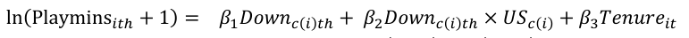

NOTE: contains mathematical notation; text above is the PDF text layer and symbols may be mis-extracted. Image shows the original.

+ 𝛼𝑖+ 𝜏𝑤+ 𝜂ℎ+ 𝜀𝑖𝑡ℎ

**equation / math rendering (image)**

NOTE: contains mathematical notation; text above is the PDF text layer and symbols may be mis-extracted. Image shows the original.

(1)

where Playmins𝑖𝑡ℎ denotes the play minutes recorded for user 𝑖 at the ℎ-th three-hour block on day 𝑡.

𝐷𝑜𝑤𝑛𝑐(𝑖)𝑡ℎ is a binary indicator representing whether Twitch was unavailable (1) or not (0) in user 𝑖’s

country 𝑐. The three-hour block takes a value of one if at least two hours within that block were affected

by the server interruption local time. We also confirm the robustness of our findings by defining the block

as affected if any portion of the three-hour block was impacted by the interruption (see Web Appendix C).

Since we do not have detailed time zone information within each country, we treated all users in the U.S.

as being in the Eastern Time Zone (UTC-4), as it is the most populated time zone in the country, covering

approximately 48% of the population (RPS Relocation 2018). To ensure robustness, we conducted a

sensitivity analysis (see Web Appendix C) by randomly assuming that some users within the U.S. were in

the Pacific Time Zone (UTC-7).

Page 21

20

𝑈𝑆𝑐(𝑖) is a binary indicator that denotes whether the user is from the United States. The

interaction between the server-down indicator and the U.S. country dummy captures any disproportionate

impact of the server down event. 𝑇𝑒𝑛𝑢𝑟𝑒𝑖𝑡 represents the number of weeks since sign-up, scaled in

logarithm. We also include user-level fixed effects (𝛼𝑖), weekly time fixed effects (𝜏𝑤), and three-hour

block fixed effects (𝜂ℎ). 𝜀𝑖𝑡ℎ is the error term.

Table 6: Impact of Twitch Service Interruption on Gameplay Minutes Model (1) (2) (3) (4) (5)

[output not shown]

NOTE: table converted from PDF layout to HTML text; cell boundaries are reconstructed. See PDF if exact alignment matters.

We report the estimated results in Table 6. In column 1, we begin with a variation of the proposed

model by including only the server-down dummy. This simple difference model captures what happens to

all users during the Twitch down event compared to normal operation days (Seiler et al. 2017). We find

that the server-down event significantly disrupts gameplay minutes (𝛽 = -.078; p<.001), indicating that

even though the video game continued to operate normally during the event, users played the game less

than usual. This provides evidence that live-streamed content and gameplay may be complements.

In column 2, we estimate the model described in Equation (1) to determine whether the average

effect identified in column 1 is more substantial in the United States, where the Twitch interruption may

Page 22

21

have been more severe due to its overlap with afternoon and evening hours. We find a negative and

highly significant effect from the interaction term (𝛽 = -.072; p < .001), indicating that the impact of the

Twitch disruption is indeed more significant for users in the United States. However, the main effect of

the server-down dummy remains negative and significant (𝛽 = -.035; p < 0.05), suggesting that users

from the European continent also reduced their gameplay minutes in response to the Twitch interruption.

This disproportionate impact aligns with our intuition that the event overlapped with more popular

gaming hours in the U.S. According to the calibration period data, about 64% of gameplay in the U.S.

(Eastern Time) occurs during the hours affected by the Twitch interruption, whereas a smaller proportion

of gameplay takes place during the same hours in European countries, such as 48% in the U.K., 37% in

Spain, 40% in France, and 32% in Ukraine.

In columns 3 to 5, we conduct robustness analyses using different variables to replicate the

disproportionate effects of the interruption. First, we assign each country a UTC offset value based on its

time zone. For example, the U.K.'s time zone during the observation period is UTC+1, so we assign a

value of one to users from this country. For all countries, we assign values according to their local time

relative to UTC. For the United States, we assume all users are in the Eastern Time Zone (UTC-4),

assigning a value of -4. As the value increases, it indicates locations further east (European continent).

Second, to account for the possibility that the interruption led some users to investigate what

happened, we use country-level Google Trends scores from August 30-31, 2017, and assign the country-

level search score as a moderator. The logic for using Google Trends is that more investigation implies

that the disruption was more impactful. Finally, we calculate the overlap between the prime gaming hours

(4 PM to midnight) and the Twitch interruption at the country level, assigning the number of overlapped

hours accordingly (represented by the number of dark cells highlighted in Table 4 by country). Across all

three models, we consistently find evidence of the disproportionate effect of the Twitch interruption, with

a more significant decrease in gameplay observed among U.S. users. For instance, the positive interaction

effect in column 3 indicates that the negative impact of the Twitch disruption dissipates as the region is

located further east of the U.S. For comparison, we compute the effect estimates for the U.S. sample as a

Page 23

22

separate row in each column. Across columns 2 to 5, we find consistent effect sizes of the Twitch

disruption on American users, showing approximately a 10% reduction in gameplay minutes during the

Twitch server down event. The overall results in Table 6 consistently demonstrate that when

livestreaming content becomes inaccessible, users tend to reduce their gameplay minutes, particularly

when the streaming service interruption occurs during prime hours for entertainment products.

5.3. Effect of Live-Streamed Content Viewing on Gameplays

Next, we will focus more closely on our primary research question: How does live-streamed content

viewing impact gameplay? To causally estimate this effect, we use the unexpected interruption of Twitch

and the user's geolocation as sources of exogenous variation. Specifically, we adopt the control function

approach to estimate the effect of interest (Papies et al. 2017, Petrin and Train 2010, Wooldridge 2015).

The core idea of the control function approach is similar to traditional instrumental variable (IV)

regression in that both use exogenous variation from instrumental variables. However, the control

function offers advantages over traditional IV regression, particularly in cases where interactions with

potentially endogenous variables are present. This is crucial for our analysis, as we wish to understand

how the effect of live-streamed content on gameplay varies with users' loyalty to different types of

streamers through interaction-based analyses. Unlike traditional IV regression, the control function

approach involves first obtaining the residuals from the first-stage regression and then including these

residuals as an additional regressor in the second-stage regression. This included residual, or control

function, not only addresses the potential selection bias of the endogenous variable (Petrin and Train

2010) but also automatically corrects for potential endogeneity issues in interaction terms, which

traditional IV regression cannot directly handle (Papies et al. 2017, Wooldridge 2015).

Our rationale for the proposed instruments is twofold: (1) the unexpected interruption of Twitch

may reduce gameplay time via a decrease in live-streamed content viewing, and (2) this reduction would

be greater when the interruption overlaps with users' prime gaming hours. While the variation related to

the Twitch interruption (1) is global and affects all users uniformly, the variation related to prime gaming

hours (2) can differ even within the same country. For example, in the U.S., our assumption that the

Page 24

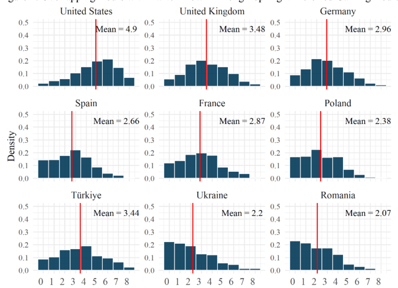

NOTE: figure/graphic rendered as an image from the PDF; its content is not machine-readable text. Caption (if any) follows as the next block.

23

Twitch disruption is more serious may hold for users who typically start playing games in the evening,

but it may not apply to users who prefer to play in the morning or during lunch hours.

To account for the potential influence of individual preferences in gaming hours, we compute the

“individual-level” influence of the Twitch interruption. To do this, we first identify the top gameplay

hours for each user based on their gaming logs during a four-week calibration period. Specifically, we

count the number of game matches played in each hour over a 24-hour period during this period. Next, we

identify the top eight hours with the highest gameplay activity for each user, treating these as their most

preferred gaming hours. We then calculate the number of hours that overlap exactly with the local time of

the Twitch disruption. By construction, the overlap hours can range from zero (indicating no overlap) to

eight (indicating full overlap). Our underlying assumption is that the overlapping hours with the Twitch

downtime among the top eight most played hours will vary within each country but will generally

increase if the region is closer to the U.S. and decrease if it is farther away. Figure 4 below illustrates the

distribution of these affected hours across different countries and provides their mean values.

Figure 4: Overlapping Hours with Twitch Down Among Top Eight Preferred Gaming Hours

Note: Color is available online. Red vertical bars indicate the positions of country-level means.

Page 25

24

The patterns in Figure 4 confirm our initial expectation that users in the U.S. were more affected

by the Twitch disruption than those in Europe. The calculations also provide individual-level information

on how much of their most preferred gaming hours were affected by the unavailability of live-streamed

content during the event. This information may substantially improve our identification of the effect, as it

allows us to capture individual differences within each country based on time preference-related shocks

from the Twitch interruption. We also observe that the distribution of overlapping hours becomes

increasingly skewed to the right as the country’s time zone is farther from the U.S. This indicates that

users in these countries were less affected, as the Twitch downtime did not significantly overlap with their

most preferred gameplay hours.

We now formulate the first-stage regression similarly to the regression framework proposed in

the previous section. However, this time, we first estimate the theoretically endogenous variable, live-

streamed content viewing minutes, using the proposed instruments and a set of control variables. We then

obtain the residuals from the first-stage regression and include them as an additional regressor in the

model where we estimate the effect of live-streamed content viewing on gameplay minutes. The full

process of the two models is described in the equations below:

*First-stage model:* ln(Viewmins𝑖𝑡ℎ+ 1) = 𝛾1𝐷𝑜𝑤𝑛𝑐(𝑖)𝑡ℎ+ 𝛾2𝐷𝑜𝑤𝑛𝑐(𝑖)𝑡ℎ× AffectedHours𝑖+ 𝛾3𝑇𝑒𝑛𝑢𝑟𝑒𝑖𝑡

**equation / math rendering (image)**

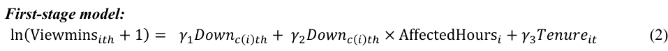

NOTE: contains mathematical notation; text above is the PDF text layer and symbols may be mis-extracted. Image shows the original.

+ 𝛼𝑖+ 𝜏𝑤+ 𝜂ℎ+ 𝜀𝑖𝑡ℎ

**equation / math rendering (image)**

NOTE: contains mathematical notation; text above is the PDF text layer and symbols may be mis-extracted. Image shows the original.

(2)

*Second-stage model:* ln(Playmins𝑖𝑡ℎ+ 1) = 𝛿1ln(Viewmins𝑖𝑡ℎ+ 1) + 𝛿2𝑇𝑒𝑛𝑢𝑟𝑒𝑖𝑡 + 𝜔̂𝑖𝑡ℎ

**equation / math rendering (image)**

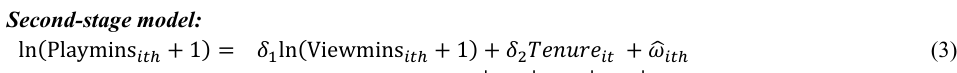

NOTE: contains mathematical notation; text above is the PDF text layer and symbols may be mis-extracted. Image shows the original.

+ 𝛼𝑖+ 𝜏𝑤+ 𝜂ℎ+ 𝜀𝑖𝑡ℎ

**equation / math rendering (image)**

NOTE: contains mathematical notation; text above is the PDF text layer and symbols may be mis-extracted. Image shows the original.

(3)

Most variables remain the same as in equation (1). Viewmins𝑖𝑡ℎ represents the view minutes of

live-streamed content recorded for user 𝑖 at ℎ-th three-hour block on day 𝑡. 𝐷𝑜𝑤𝑛𝑐(𝑖)𝑡ℎ is our instrument

that denotes the Twitch interruption. This is interacted with AffectedHours𝑖, which represents the

overlapping hours with the Twitch downtime among the eight most preferred gaming hours of each user.

Theoretically, 𝛾1 captures the overall impact of the unexpected Twitch interruption on all users, while 𝛾2

adjusts the effect based on the number of each user’s preferred gaming hours that overlap with the event.

Page 26

25

Finally, 𝜔̂𝑖𝑡ℎ denotes the residuals from the first-stage regression, which will adjust for the potential

influence of the endogenous component of the live-streamed content viewing variable.

Table 7 reports the estimated results of our two-stage model. The first-stage regression results

yielded the expected findings. The unexpected Twitch interruption created a significant disruption in live-

streamed content viewing time, which is more pronounced for users whose preferred gaming hours

overlapped with the period of Twitch unavailability. This implies that the impact of the Twitch downtime

is not uniform across all users but is amplified for those whose gaming schedules are more severely

affected by the interruption. This highlights the importance of accounting for individual-level differences

in time preferences when assessing the overall effect. This pattern may also reflect that users whose prime

gaming hours overlap more with the Twitch downtime experience an even greater reduction in viewing

minutes compared to similar prime gaming hours when Twitch was available. This suggests that gaming

and viewing behaviors are closely interlinked. We find that our instruments are empirically valid as well,

as the F-statistics for both variables are statistically significant and exceed the commonly recommended

threshold of 10 for assessing the strength of instruments.

Table 7: Elasticity of Gameplay Minutes Relative to Streaming Content View Minutes

[output not shown]

NOTE: table converted from PDF layout to HTML text; cell boundaries are reconstructed. See PDF if exact alignment matters.

Note: *p<.05; **p<.01; ***p<.001. The number of observations is 2,837,240. For the first stage, clustered standard errors at the user level were used. For the second stage, bootstrapped standard errors from 50 resamples were used.

Page 27

26

In the second-stage model, we confirm that the impact of live-streamed content viewing on play

minutes is positive and statistically significant. The estimated elasticity is .308, which implies that a 10%

increase in live-streamed content viewing minutes results in approximately a 3.08% increase in gameplay

minutes. We also find that the estimate for the control function is statistically significant, indicating that

endogeneity bias is present and is being controlled for. The negative estimate of the control function

suggests that unobserved factors that increase viewing time are associated with a decrease in play

minutes. If left unaddressed, this factor could lead to an underestimation of the true effect.

5.4. Processes: How Exactly Does Livestreaming Complement Gameplays?

The previous analysis confirms the positive impact of livestreaming content on gameplay. However,

exactly *how* live-streamed content influences gameplay of the promoted products remains unclear. To

understand the processes further, we consider two possible processes through which live-streamed content

can complement gameplay and analyze the data descriptively to determine which is more likely based on

empirical evidence.

5.4.1. Concurrent consumption

One potential way livestreaming content can increase gameplay is by encouraging people to enjoy both

activities *concurrently*. Individuals may enjoy playing the video game while simultaneously watching

someone else’s gameplay on the livestreaming platform. Anecdotal evidence suggests that some users

prefer this concurrent consumption (Ashworth 2022), a practice similar to using smartphones while

watching television (commonly referred to as “second screening”) (Van Cauwenberge et al. 2014). To

examine this possibility, we merge the viewing and gameplay logs to measure the overlap in the two

activities. Specifically, we calculate the ratio of minutes users spent on both activities to the total viewing

minutes of live-streamed content. A ratio of zero would indicate no concurrent consumption, while a ratio

of one would indicate complete concurrent consumption.

We find that the concurrent consumption rates for users have many non-zero values but are quite

low overall. The median rate is 4.28%, with an interquartile range from 0% (25th percentile) to 13.78%

Page 28

27

statistics suggest that most users do not engage in concurrent consumption, and even when they do, it

occurs very rarely or mildly. This implies that while concurrent consumption happens, few users engage

in it to a significant extent.

5.4.2. Sequential consumption

Another way streamed content may influence gameplay is if users play the focal games *sequentially*

within a reasonably close time frame. For instance, some users may have routines where they watch

streamed content first, finish their viewing, and then play the game afterward. If this is the case, streamed

content can complement the consumption of the focal video game in a sequential rather than simultaneous

manner. To examine this possibility, we track each user's viewing sessions during the calibration period.

On average, users spend 38 minutes (with a standard deviation of 60.95) on each viewing of streamed

content, with an interquartile range from 5 minutes (25th percentile) to 42 minutes (75th percentile). From

the end timestamp of each viewing session, we recorded whether there were any follow-up video game

plays within three hours (180 minutes). We assign a value of one if there were follow-up gameplays and

zero otherwise, and then calculate the ratio of viewing sessions with follow-up gameplay as the

probability of playing games after viewing a livestreaming session.

Figure 5 reports the results of the descriptive analyses along with the statistical range of

significance. We generate these statistics based on the type of streamers (firm-owned, mega, micro) the

user watched most during the viewing session. Additionally, we split the sample based on loyalty status—

whether the user has developed loyalty to the streamer or not. For comparison, we compute the proportion

of three-hour time blocks with any gaming activity for each day without any viewing activity. We find

that the ratio of three-hour blocks with gaming activity was 13.77% when the user did not watch any

streamed content that day.

The statistics in Figure 5 provide two key insights. First, compared to gameplay rates on days

without streaming activity (13.77%), users are more likely to play the video game within three hours after

viewing ends (approximately 29%, based on the lowest figure). This suggests that streamed content is

Page 29

28

associated with follow-up gameplay. Viewed in conjunction with the previous results related to

simultaneous play and viewing, these results suggest that viewing and playing are experienced mostly

sequentially. Second, the probability of follow-up gameplay is lower when users spend most of their time

watching mega streamers compared to firm-owned channels or micro streamers, regardless of loyalty

status. This reduced gameplay after watching mega streamers is more pronounced when the user is loyal

to the streamer (about a three percentage point reduction) than when they are not (about a two percentage

point reduction). This suggests that while streaming content generally promotes follow-up gameplay, its

effectiveness varies depending on the streamer type and the user's loyalty. Watching mega streamers may

be less effective in driving subsequent gameplay, particularly when users are loyal to the streamer.

Figure 5: Probability of Follow-up Gameplay After Watching Loyal vs. Non-loyal Live Streamers

Note: Color is available online. Error bars denote standard errors.

5.4.3. Summary

The preceding analyses confirm both the concurrent and sequential impacts of watching live-streamed

content on gameplay. While we recognize that both processes occur, our findings suggest that the more

dominant effect is sequential consumption. Notably, we find that the patterns of sequential consumption

vary based on users' loyalty status to various streamer types. Specifically, content created by firm-owned

channels or micro streamers tends to motivate follow-up gameplay at a higher rate than content from

mega streamers. This is an interesting finding, considering that mega streamers are often the primary

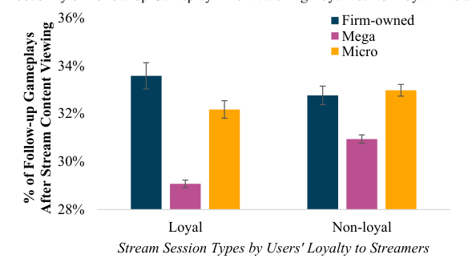

NOTE: figure/graphic rendered as an image from the PDF; its content is not machine-readable text. Caption (if any) follows as the next block.

**text found inside the figure**

28%

30%

32%

34%

36%

Loyal Non-loyal

**% of Follow-up Gameplays**

**After Stream Content Viewing**

*Stream Session Types by Users' Loyalty to Streamers*

Firm-owned Mega Micro

Page 30

29

targets for sponsorships by firms. While their audiences are larger, their effectiveness in prompting

sequential gameplay appears relatively weaker. In addition, we observe that loyalty to mega streamers

may further reduce follow-up gameplay. There is a logic to this result as the mega streamers' popularity

suggests they may have more appealing content and may, therefore, cross a threshold and start to shift

from complement to substitute.

5.5. Streamer Types and User-level Heterogeneity by Loyalty Formation

Our previous analyses have addressed several questions: whether, to what extent, and how live-streamed

content supports the usage of the promoted video game. The results are promising for video game

franchises, as they provide evidence that supports and justifies investments in creators on livestreaming

platforms to help create a game community or fandom. However, as indicated by our descriptive analysis

of consumption processes, it is possible that this positive effect may vary depending on a user's propensity

for loyalty to different streamer types. This is a managerially important question because it directly

addresses “to whom” the consumption of live-streamed content is most effective.

Our research examines outcomes from a context involving a fandom community focused on some

source material (the game) and peripheral creators (streamers) who make content related to the source

material. This type of consumption community is increasingly prevalent in the entertainment sector and

social media spaces. Extant research has begun examining questions related to peripheral content

creators’ (Cheng and Zhang 2024, Tian et al. 2024) and source-material producers’ heterogeneity and

decisions (Huang and Morozov 2024, Jo and Lewis 2024). A primary differentiator of our research is our

more detailed focus on the consumption community's members (gamers).

As discussed earlier, we compute loyalty to a certain type of streamer as the ratio of time spent

watching that type of streamer to total viewing minutes during the calibration period. A user was

considered loyal to a specific streamer if they visited that streamer eight times (twice a week) during the

four-week calibration period. We computed three distinct loyalty variables at the individual level by

categorizing the viewing minutes spent on the three types of streamer accounts: firm-owned, mega

Page 31

30

streamers, and micro streamers. These variables allow us to categorize viewers based on their propensity

to repeatedly view firm-controlled content (loyal to the firm-owned channel), content created by “big

names” (loyalty to mega streamers), or niche content created by small to medium-sized creators (loyalty

to micro streamers).

To understand the roles of streamer type preference and heterogeneity, we conduct additional

analyses to examine the differential impact of live-streamed content consumption based on users' loyalty

to three distinct streamer groups: firm-owned, mega-, and micro-streamers. These variables were centered

on their means and interacted with streamed content viewing minutes. These interactions reveal how the

relationship between streamed content viewing and gameplay varies based on the user's loyalty traits. We

follow the same control function approach in Equations (2) and (3) and add the loyalty interactions with

view minutes in Equation (3). To ensure robustness in operationalization, we report three distinct sets of

analyses using alternative definitions of loyalty (four, eight, and twelve visits to a particular streamer).

Table 8: Heterogeneous Effect by Loyalty Formation to Different Streamer Groups

| Loyaltyisdefinedas: | 4repeatedvisits duringthe calibrationperiod | 8repeatedvisits duringthe calibrationperiod | 12repeatedvisits duringthe calibrationperiod |
| --- | --- | --- | --- |
| Model | (1) | (2) | (3) |
| ln(Viewmins𝑖𝑡ℎ + 1) | 303*** . | 304*** . | 303*** . |
| ln(Viewmins𝑖𝑡ℎ + 1) × 𝑳𝒐𝒚𝒂𝒍𝒕𝒚𝑖FirmOwned | (044) . -.086*** | (049) . -.054 ** | (059) . -.065** |
| ln(Viewmins𝑖𝑡ℎ + 1) × 𝑳𝒐𝒚𝒂𝒍𝒕𝒚 𝑖Mega | (012) . -.085*** | (020) . -.072 *** | (024) . -.068*** |
| ln(Viewmins𝑖𝑡ℎ + 1) × 𝑳𝒐𝒚𝒂𝒍𝒕𝒚𝑖Micro | (008) . 149*** . | (008) . 175*** . | (009) . 187*** . |
| Tenure𝑖𝑡 | (018) . 055 -. | (020) . 062 -. | (022) . 060 -. |
| 𝜔̂ (control function) 𝑖𝑡ℎ | (129) . -.117** (044) . | (131) . -.118 * (049) . | (129) . -.117* (060) . |
| IndividualuserFEs WeeklytimeFEs Three-hour block FEs | Included Included Included | Included Included Included | Included Included Included |
| Rsquared Rsquared(adj) . | 183 . 180 . | 183 . 180 . | 182 . 179 . |

NOTE: table converted from PDF layout to HTML text; cell boundaries are reconstructed. See PDF if exact alignment matters.

Page 32

31

Table 8 presents the estimation results of the extended equation (3) analysis. The main effect

indicates the causal impact of live-streamed content viewing for users with an average level of loyalty

across the three types of streamer groups. Because we primarily define loyalty as *eight* repeated visits of

users to a streamer during the calibration period, we interpret the results based on Model (2). However,

we find that the estimates' overall patterns and statistical significance remain qualitatively consistent with

alternative operationalizations. The results in Table 8 reveal several interesting findings. First, we

replicate a positive and significant main effect of live-streamed content viewing on gameplay. This

positive effect diminishes as users become more loyal to firm-owned channels or mega streamers. This

suggests that while watching live-streamed content still encourages viewers to play the promoted video

game, loyalty to certain content creators may reduce the content's effectiveness.

Interestingly, we observe the opposite pattern when users are more loyal to niche and small

streamers (micro streamers). The positive moderation indicates that live-streamed content is particularly

effective in motivating users to play the focal game after watching if they are more loyal to micro

streamers. To fully evaluate these adjustments within the range of observed data, we compute and

visually plot the three distinct values of each loyalty variable in Figure 6. Specifically, using the results of

model (2) in Table 8, we compute the adjusted effect of live-streamed content on gameplay for three

loyalty statuses: no loyalty (loyalty variable equals zero), low loyalty (25th percentile among loyalty

variables greater than zero), and high loyalty (75th percentile among loyalty variables greater than zero).

The results in Figure 6 show that while the effect size decreases in the cases of loyalty to firm-

owned channels and mega streamers, the reductions substantially differ in magnitude. Specifically, if we

compute the difference between “no loyalty” and “high loyalty,” the reduction associated with loyalty to

firm-owned channels is relatively small (-8.53%), whereas the reduction for mega streamers is nearly

twice as large (-16.66%). This highlights that loyalty to “big” independent streamers dilutes the loyalty to

the endorsed product and may significantly decrease the positive effect of live-streamed content.

Page 33

32

Figure 6: Elasticity of Streamed Content Viewing on Gameplay by Loyalty Formation

Note: Color is available online. The statistical significance of the adjustment (in %) between “high loyalty” and “no loyalty” is shown.

However, the relatively smaller reduction for firm-owned channels suggests that these channels

may still play an effective role in maintaining a connection between the brand and the audience. Since

firm-owned channels can directly control the narrative and consistently deliver brand-focused content,

they offer a strategic advantage in ensuring that viewership remains tied to the product, even with a slight

reduction in effect size. This allows firms to maintain a direct, loyal customer base while reinforcing

product engagement. In contrast, when customers develop loyalty to mega streamers, the beneficial

effects of watching streamed content are significantly less than when loyalty exists to a firm-owned

account. We speculate that the mega streamers' higher production values and reduced capability for

interaction lead to less community-focused programming and, therefore, less complimentary.

In the case of loyalty to micro streamers, we find the opposite pattern as the positive effect grows

as loyalty increases. The adjusted effect magnitude reaches 36% when comparing the effect estimates

between “no loyalty” and “high loyalty” (Figure 6). Critically, the effects shrink as loyalty to mega and

firm owned streamers increases. These findings are vital because they highlight how content created by

streamers with niche and small to medium-sized fan bases can contribute positively to the fandom

economy. Unlike firm-owned or mega streamers, micro streamers typically do not have excessively large

audiences, allowing them to produce content almost in real-time while maintaining interaction with their

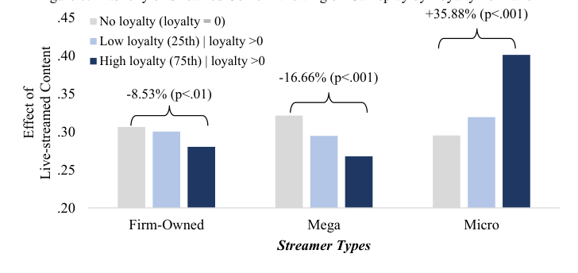

NOTE: figure/graphic rendered as an image from the PDF; its content is not machine-readable text. Caption (if any) follows as the next block.

**text found inside the figure**

.20

.25

.30

.35

.40

.45

Firm-Owned Mega Micro

Effect of

Live-streamed Content

*Streamer Types*

No loyalty (loyalty = 0) Low loyalty (25th) | loyalty >0 High loyalty (75th) | loyalty >0

-8.53% (p<.01)

-16.66% (p<.001)

+35.88% (p<.001)

Page 34

| Robustnesschecks | Resultsavailableat: |
| --- | --- |
| •Alternativeoperationalizationfor“Down”dummy | WA C1 - . |
| •AlternativetimezoneassumptionforUS sample . . | WA C2 - . |
| •Alternativeoperationalizationsofaffectedhours | WA C3 - . |
| •Alternativeoperationalizationforloyaltyvariable | Table8 |
| •Additionalcontrolsforunobservables |  |
| Include country-level linear time trends - | WA C4 - . |
| Replace week fixed effects with daily fixed effects - | WA C4 - . |
| Add day-of -week fixed effects - | WA C4 - . |
| •Replicationswithsubsetsofdata |  |
| Use data from the week of the Twitch interruption only - | WA C5 - . |
| - Replicate with users accounting for 99% of playtime | WA C5 - . |
| - Replicate with users accounting for 95% of playtime | WA C5 - . |

NOTE: table converted from PDF layout to HTML text; cell boundaries are reconstructed. See PDF if exact alignment matters.

33

viewers. Our speculation is this flexibility enables them to tailor their content to audience preferences

better, creating a balanced focus on both the streamer and the promoted content.

5.6. Robustness Analyses

We also performed a series of supplementary analyses to ensure the robustness of our findings. A

reasonable concern regarding our empirical analyses is whether the results may be artifacts of specific

operationalizations of certain variables. We replicate the analyses using alternative operationalizations for

our key variables to address this. These include alternative assumptions for time zones in the U.S. sample

and stricter or more relaxed definitions of loyalty variables. For conciseness, we provide a summary of

the supplementary analyses conducted in Table 9. A comprehensive list of all supplementary analyses and

detailed methodologies and results is available in the Web Appendix C.

Table 9: Robustness Analyses Robustness checks Results available at: • Alternative operationalization for “Down” dummy WA-C.1 • Alternative time zone assumption for U.S. sample WA-C.2 • Alternative operationalizations of affected hours WA-C.3 • Alternative operationalization for loyalty variable Table 8 • Additional controls for unobservables - Include country-level linear time trends WA-C.4 - Replace week fixed effects with daily fixed effects WA-C.4 - Add day-of-week fixed effects WA-C.4 • Replications with subsets of data - Use data from the week of the Twitch interruption only WA-C.5 - Replicate with users accounting for 99% of playtime WA-C.5 - Replicate with users accounting for 95% of playtime WA-C.5 Note: WA denotes Web Appendix. **6. Conclusion**

Social media platforms have provided opportunities for independent creators to create content focused on

source material from categories like video games, sports, and music. Live streamers are an especially

important type of creator as these performers can develop substantial, loyal followings and interact with

their audiences. The growth of livestreaming services has led many firms to sponsor creators on these

platforms to promote products and enhance customer engagement. Understanding the effectiveness of

Page 35

34

these endorsements is critical for firms, particularly when deciding how to allocate sponsorship budgets to

these personalities.

Our research examines the impact of watching different types of live streamers on video game

engagement. We find that when users watch content created by live streamers, it results in increased

gameplay of the featured video game. This finding supports previous aggregate-level analyses at the game

title level (Huang and Morozov 2024). The strength of our study is that user-level data allows us to

examine the detailed process of this complementary relationship and the moderation effects of loyalty

formation. Specifically, our study indicates that live-streamed content and video games can be consumed

either (1) concurrently or (2) sequentially; however, sequential consumption emerges as the more

dominant form for most users. Additionally, we find that the positive effect of live-streamed content

significantly varies based on user-level traits related to loyalty (i.e., repeated consumption of a specific

creator). Loyalty to mega streamers turns out to reduce the positive effect, while loyalty to micro

streamers augments it. Furthermore, loyalty to firm-owned content slightly diminishes the positive effect,

although this reduction is about half the size of the decrease observed with loyalty to mega streamers.

6.1. Contribution to Research and Theory

Our research extends the marketing literature on the creator economy in several respects. First, we take a

novel empirical approach to explore the fundamental question of whether, to what extent, and how live-

streamed content influences the usage of an endorsed product. By leveraging the unexpected interruption

of the largest livestreaming platform globally, we identify the causal effect of live-streamed content

viewing on the consumption of the endorsed product. This approach is a significant addition to the

literature, given that most datasets available in this context are scraped, limiting the research scope and

creating challenges to establishing causality.

Second, we extend the understanding of peripheral content creators by examining the underlying

process of *how* their content complements the core material. Specifically, we investigate two plausible

consumption processes: concurrent and sequential consumption of live-streamed content and video game

Page 36

35

products. Our analysis of data patterns finds that sequential consumption is the more dominant behavior

among users. This finding is important as it enhances previous research by focusing on user-level

behaviors, unlike past studies that were limited to product- or creator-level analysis (Huang and Morozov

2024, Li et al. 2024) and could not fully capture how creator content drives individual users’ engagement.

The pattern of sequential consumption is important because it suggests some type of feedback mechanism

where viewing leads to play. This is a salient finding as it may allow core products to define more

beneficial incentive structures for their partners. If viewing and playing were concurrent, the ideal

incentive structure would emphasize the length of sessions. Given that consumption is sequential, the

ideal incentive structure would emphasize conversion rates.

Finally, and most importantly, our research addresses a significantly under-researched aspect of

the creator economy: the role of user loyalty to streamers. While academic research on the role of creators

is not entirely new in marketing, most studies have focused on creator-level heterogeneity (Li et al. 2024,

Tian et al. 2024) or the use of livestreaming platforms from the perspective of a core product that

sponsors live streamers (Huang and Morozov 2024, Jo and Lewis 2024). These efforts provide valuable

insights for business practice, but our study differentiates itself by focusing on one of the most critical

aspects of the creator economy (Figure 1): the users themselves. Users do not consume creator content

randomly; some encounter it by chance, while others genuinely enjoy the content, repeatedly visiting and

consistently following the creator’s new releases. Creators are motivated to build large and loyal

audiences. Consumer preferences for different types of creators partially determine the structure of the

consumption community. When consumers choose to watch specific creators repeatedly, relationships

begin to form, and those creators may become more influential.

Our empirical analyses explore whether this loyalty or fandom toward specific types of streamers

influences the relative effectiveness of streamed content in motivating consumption of the core product.

This perspective provides a new way to understand the dynamics of the creator economy, an area that has

received little attention in previous research primarily due to data granularity. Most studies rely on

product-level data (Huang and Morozov 2024, Li et al. 2024) or social media post-level (Tian et al. 2024)

Page 37

36

information, which makes it difficult to capture user-level heterogeneity. By leveraging granular user-

level data, we expand the scope of the current literature by examining how the relationship between

streamed content and endorsed products varies according to users' loyalty to different streamer groups.

This is an essential extension as it acknowledges that these consumption or fandom communities are

complex networks of complimentary products that build the overall fandom and compete for individual

fans.

6.2. Contribution to Managerial Practice

Our research also offers several managerial implications for the increasing practice of selecting external

creators to endorse products. First, we find a causal and positive effect of live-streamed content

consumption on the consumption of the endorsed product. This is an important finding, as managers need

to justify the marketing budget allocated to working with creators to increase product awareness. Our

estimate suggests an elasticity of .308, meaning that a 10% increase in live-streamed content viewing

leads to approximately a 3.08% increase in gameplay time. Second, our research challenges the most

common approach in the industry: hiring “big names” may not always be optimal. Our findings indicate

that when users are highly loyal to mega streamers, the relative effectiveness of live-streamed content

decreases, revealing that loyalty to streamers does not always translate to loyalty to the endorsed product.

In contrast, we find that loyalty to micro streamers substantially increases the positive effect of streamed

content. Decisions on collaboration should reflect nuances between “big names” and “niche artists.”

Third, unlike the significant reduction in positive effects associated with loyalty to mega

streamers, we find that the reduction in positive effect is substantially smaller (about half) when a user

forms loyalty to a firm-owned channel. This is important because it implies investing in a firm-owned

streaming channel does not adversely affect the complementarity between live-streamed content and the

firm’s product, as other popular mega streamer channels do. Finally, our findings on user-level

heterogeneity in loyalty may be valuable for many firms, as they can inform a targeting strategy to

categorize customers into multiple segments. Given that the marketing budget to engage users is often

Page 38

37

limited, understanding who is more receptive to content created by live streamers can provide useful

insights for firms to promote trials of their content.

Conceptualizing the value creation process as a multifaceted ecosystem is also an important

managerial contribution as it clarifies that many content creators operate within and potentially enhance

consumption communities. Our context is video games, but the phenomenon is more general. A lifestyle

influencer might create content around specific designers or brands, while a sports influencer might

develop content about a specific team. In all these cases, a consumption community or fandom develops

around not just a core product but also peripheral and complementary products, services, and activities. In

these circumstances, the value provided to consumers is provided by a web or network of entities rather

than through a linear value chain.

6.3. Limitations and Avenues for Future Research

The study is subject to limitations that suggest avenues for future research. First, our data is limited to

existing players of the specific video game. This data is appropriate for our goal of understanding the link

between the consumption of streaming content and the consumption of the game. However, creators

might also affect customer acquisitions. Future research might examine the relationship between watching

streams and new game downloads (or new product trials). This type of study would require greater access

to user data from streaming platforms. Second, our research focuses on relatively near-term consumer

response. Researchers may also wish to investigate how influencer content affects long-term customer

retention. With different data scaling and modeling strategies, it would be interesting to see if watching

creators’ livestreams might decrease customer churn. Finally, our study does not consider the

unstructured data generated in live streams (e.g., analyses of videos) because most videos are not

archived. However, it would be worthwhile to extract metrics on streamer-viewer interactions and

investigate whether they are associated with subsequent plays and purchases.

Page 39

38

#### **7. References**

Ashworth M (2022) How to Watch Twitch While Playing PS5 Games. *PlayStation LifeStyle* (July 18)

https://www.playstationlifestyle.net/2022/07/18/how-to-watch-twitch-while-playing-ps5-gamespip-splitscreen/. Bhargava HK (2022) The Creator Economy: Managing Ecosystem Supply, Revenue Sharing, and

Platform Design. *Management Science* 68(7):5233–5251. Brown F (2020) Ninja allegedly made $20-30 million by moving to Mixer. *PC Gamer* (January 28)

https://www.pcgamer.com/ninja-allegedly-made-dollar20-30-million-by-moving-to-mixer/. Cheng M (Magie), Zhang S (2024) Reputation Burning: Analyzing the Impact of Brand Sponsorship on

Social Influencers. *Management Science* Forthcoming. Dean B (2024) Twitch Usage and Growth Statistics: How Many People Use Twitch? *Backlinko*.

Retrieved (September 10, 2024), https://backlinko.com/twitch-users. Feng X (Flora), Zhang S, Liu X, Srinivasan K, Lamberton CP (2024) An AI Method to Score Celebrity

Visual Potential from Human Faces. *Journal of Marketing Research* Forthcoming. Ford C, Gardner D, Horgan LE, Liu C, Tsaasan AM, Nardi B, Rickman J (2017) Chat Speed OP

PogChamp: Practices of Coherence in Massive Twitch Chat. *Proceedings of the 2017 CHI Conference Extended Abstracts on Human Factors in Computing Systems*. (ACM, Denver Colorado USA), 858–871. Gu X, Zhang X, Kannan PK (2024) Influencer Mix Strategies in Livestream Commerce: Impact on

Product Sales. *Journal of Marketing* 88(4):64–83. Huang Y, Morozov I (2024) The Promotional Effects of Live Streams by Twitch Influencers by Yufeng

Huang, Ilya Morozov :: SSRN. *Marketing Science* Forthcoming. Hughes C, Swaminathan V, Brooks G (2019) Driving Brand Engagement Through Online Social

Influencers: An Empirical Investigation of Sponsored Blogging Campaigns. *Journal of Marketing* 83(5):78–96. Influencer Marketing Hub (2021) The State of Influencer Marketing 2021: Benchmark Report. *Influencer*

*Marketing Hub*. Retrieved https://influencermarketinghub.com/influencer-marketing-benchmarkreport-2021/. Inmar Intelligence (2021) Inmar Intelligence Survey Result. Retrieved

https://www.inmar.com/blog/press/inmar-intelligence-survey-finds-84-percent-shoppers-havemade-purchase-based-influencers. Jo W, Lewis M (2024) Sponsored Product-Based Competition and Customer Engagement: A Study of an

Esports Competition in the Video Game Industry. *Production and Operations Management* 33(3):795–816. Leung FF, Gu FF, Li Y, Zhang JZ, Palmatier RW (2022) Influencer Marketing Effectiveness. *Journal of*

*Marketing* 86(6):93–115. Lewis M (2024) *Fandom Analytics: Creating and Harnessing Consumer and Cultural Passion* (Springer

Nature Switzerland, Cham). Li N, Haviv A, Lovett MJ (2024) Opposing Influences of YouTube Influencers: Purchase and Usage

Effects in the Video Game Industry. *Working*. Lu S, Yao D, Chen X, Grewal R (2021) Do Larger Audiences Generate Greater Revenues under Pay

What You Want? Evidence from a Live Streaming Platform. *Marketing Science* 40(5):813–1007. Muller S (2024) Tyler ‘Ninja’ Blevins Reveals The Secret To Brand Partnerships. *Forbes* (July 8)

https://www.forbes.com/sites/sarahmuller/2024/07/08/creator-economy-tyler-blevins-ninjanutcase-content-creator/. Netflix (2024) What We Watched the First Half of 2024. *About Netflix*. Retrieved (September 24, 2024),

https://about.netflix.com/news/what-we-watched-the-first-half-of-2024. Papies D, Ebbes P, Van Heerde HJ (2017) Addressing Endogeneity in Marketing Models. *Advanced*

*Methods for Modeling Markets*. International Series in Quantitative Marketing. (Springer International Publishing, Cham), 581–627.

Page 40

39

Petrin A, Train K (2010) A Control Function Approach to Endogeneity in Consumer Choice Models.

*Journal of Marketing Research* 47(1):3–13. RPS Relocation (2018) American Cities by Time Zone. *RPS Relocation Blog* (July 17)

https://www.rpsrelocation.com/blog/data-visualization/american-cities-by-time-zone/. Seiler S, Yao S, Wang W (2017) Does Online Word of Mouth Increase Demand? (And How?) Evidence

from a Natural Experiment. *Marketing Science* 36(6):838–861. Spangler T (2024) Netflix’s Ad Tier Now Has More Than 23 Million Monthly Active Users, Advertising

Chief Says. *Variety* (January 10) https://variety.com/2024/tv/news/netflixs-ad-tier-23-millionmonthly-users-1235868024/. SullyGnome (2024) Most watched games on Twitch - SullyGnome (January 2024). Retrieved (June 2,

2021), https://sullygnome.com/games/2024january/watched. Tian Z, Dew R, Iyengar R (2024) Mega or Micro? Influencer Selection Using Follower Elasticity.

*Journal of Marketing Research* 61(3):472–495. Tylwalk N (2017) Twitch was down all day, and here are some of our favorite Twitter reactions.

*FanSided* (August 31) https://fansided.com/2017/08/31/twitch-down-all-day-twitter-reacts/. Van Cauwenberge A, Schaap G, van Roy R (2014) “TV no longer commands our full attention”: Effects

of second-screen viewing and task relevance on cognitive load and learning from news. *Computers in Human Behavior* 38:100–109. Wooldridge JM (2015) Control Function Methods in Applied Econometrics. *J. Human Resources*

50(2):420–445.

Page 41

WA-1

Can Loyalty to Creators Dilute Loyalty to Promoted Products?

Examining the Heterogeneous Effects of Live Streamed Content on Video Game Usage

Web Appendix

*A. Details on Twitch Server Down Events*

*B. Determination of Typical Gaming Hours Within a Day*

*C. Robustness Checks*

*1. Alternative operationalization of “Down” dummy*

*2. Alternative time zone assumption for U.S. sample*

*3. Alternative operationalizations of affected hours*

*4. Additional controls for unobservables*

*5. Replications with subsets of data*

Page 42

WA-2

#### *A. Details on Twitch Server Down Events*

Here, we provide further details about the unexpected service outage of Twitch.tv that occurred from

August 30 to 31, 2017. We present a set of anecdotal evidence to demonstrate the existence of this

exogenous shock.

*A.1. Twitch Announcements on Social Media*

Once the website began experiencing issues with user access, Twitch’s support team started investigating

the problem. However, since the website was not loading properly for many users, the firm used their

support team’s Twitter account to inform users about the issue and provide updates on their progress.

Table A1 below shows the timeline of the event with screenshots from their social media account. This

indicates that the service interruption began around 3 PM on August 30 (US Eastern Time) and continued

until at least 1:00 AM on August 31 (US Eastern Time), which is the period used for our identification.

Table A1: Tweets of @TwitchSupport at Twitter Timeline Screenshot 3:54 PM Aug 30, 2017 (US Eastern Time)

[figure not shown]

NOTE: figure/graphic rendered as an image from the PDF; its content is not machine-readable text. Caption (if any) follows as the next block.

**text found inside the figure**

4:48 PM Aug 30, 2017 (US Eastern Time)

7:32 PM Aug 30, 2017 (US Eastern Time)

Page 43

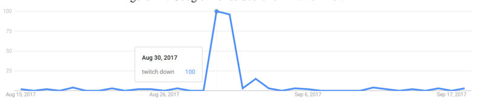

NOTE: figure/graphic rendered as an image from the PDF; its content is not machine-readable text. Caption (if any) follows as the next block.

WA-3

[figure not shown]

NOTE: figure/graphic rendered as an image from the PDF; its content is not machine-readable text. Caption (if any) follows as the next block.

**text found inside the figure**

0:07 AM Aug 31, 2017 (US Eastern Time)

*A.2. "Twitch Down" Search Volume Measured on Google Trends*

When a favorite website does not load properly, the natural reaction is to use a search platform to find out

if something is wrong with the site. If a service outage truly occurred, we would expect to see a sudden

spike in web searches inquiring about the status of Twitch. To capture this, we obtained worldwide search

trends for the keyword "Twitch down" for approximately two weeks before and after the outage period.

As illustrated in Figure A1 below, there is a clear and significant surge in search volume during the two-

day period (August 30-31, 2017) when the interruption occurred.

Figure A1: Google Trends Score for “Twitch Down”

Note: The raw data for this figure can be accessed at (public url): https://trends.google.com/trends/explore?date=2017-08-15%202017-09-18&q=twitch%20down&hl=en

Page 44

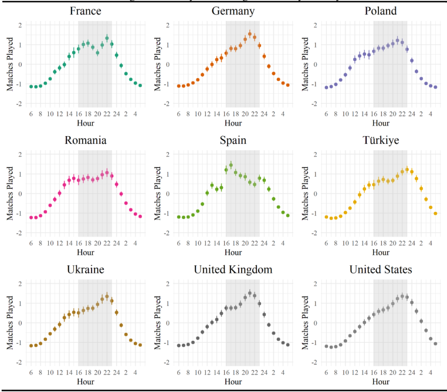

NOTE: figure/graphic rendered as an image from the PDF; its content is not machine-readable text. Caption (if any) follows as the next block.

WA-4

#### *B. Determination of Typical Gaming Hours Within a Day*

In the main manuscript, we assume that people in any country typically engage with video game products

from the late afternoon (4 PM) to midnight. While this assumption is reasonable, we ensure that this

pattern is supported by our dataset. To validate this, we revisit the raw data and construct a country-day-

hour panel dataset. The dataset includes nine countries from our sample, 63 unique days during our

observation period (July 18 to September 18, 2017), and 24 unique hours within a day. For each

observation, we count the number of game matches initiated at each country, day, and hour. Finally, we

create a country-by-hour plot showing the average standardized number of game matches played, with

95% confidence intervals. These patterns are presented in Figure B below.

Figure B: Hourly Game Usage Patterns by Country

Note: Colors are available online. Dots represent standardized game matches played by country, with 95% confidence intervals shown as error bars. All gaming hours are in local time. The x-axis covers a 24-hour period, starting at 6:00 AM, with labels in two-hour intervals. The grey area highlights matches played from 4:00 PM to 11:59 PM.

Page 45

WA-5

typical gaming hours for players in our *5.2. Geography-Based Analysis* section. As a follow-up, we create

individual-level typical gaming hours to compute the elasticity of live-streamed content on gameplay.

Further details are provided in *5.3 Effect of Live Streamed Content Viewing on Gameplays*.

Page 46

WA-6

#### *C.1. Robustness Checks: Alternative operationalization of “Down” dummy*

We operationalize the Down𝑐(𝑖)𝑡ℎ dummy variable in Equation (2) by defining a three-hour block as

affected if at least two of its hours were impacted by the Twitch interruption. To ensure robustness, we

redefine the Down𝑐(𝑖)𝑡ℎ dummy by assigning a value of one to three-hour blocks if **any portion** of the

block overlapped with the Twitch interruption. The results of our analyses are presented in Table C1

below. We find that the overall main findings remain qualitatively consistent.

Table C1: Robustness Checks Using Alternative Operationalization of Down Dummy

| Description | First -stage | Second -stage: Main | Second -stage: Interaction |
| --- | --- | --- | --- |
| Dependentvariable | ln(Viewmins𝑖𝑡ℎ+ 1) ln(Playmins𝑖𝑡ℎ+ 1) ln(Playmins𝑖𝑡ℎ+ 1) |  |  |
| Model | (1) | (2) | (3) |
| ln(Viewmins𝑖𝑡ℎ + 1) |  | 285*** . | 282*** . |
| ln(Viewmins𝑖𝑡ℎ + 1) × 𝑳𝒐𝒚𝒂𝒍𝒕𝒚𝑖Firm−owned |  | (053) . | (049) . -.054** |
| ln(Viewmins𝑖𝑡ℎ + 1) × 𝑳𝒐𝒚𝒂𝒍𝒕𝒚 𝑖Mega |  |  | (020) . -.072*** |
| ln(Viewmins𝑖𝑡ℎ + 1) × 𝑳𝒐𝒚𝒂𝒍𝒕𝒚𝑖Micro |  |  | (008) . 175*** . |
| Down 𝑐(𝑖)𝑡ℎ | -.172*** |  | (019) . |
| Down 𝑐(𝑖)𝑡ℎ × AffectedHours𝑖 | (006) . -.012*** |  |  |
| Tenure𝑖𝑡 | (003) . -.347** | 063 -. | 069 -. |
| 𝜔̂ (control function) 𝑖𝑡ℎ | (108) . | (142) . -.102a (054) . | (136) . -.096* (048) . |
| F -statistics of: |  |  |  |
| Down 𝑐(𝑖)𝑡ℎ Down 𝑐(𝑖)𝑡ℎ × AffectedHours𝑖 | 788189*** . 2029*** . |  |  |
| IndividualuserFEs WeeklytimeFEs Three-hour block FEs | Yes Yes Yes | Yes Yes Yes | Yes Yes Yes |
| Rsquared Rsquared(adj) . | 190 . 188 . | 181 . 179 . | 183 . 180 . |

NOTE: table converted from PDF layout to HTML text; cell boundaries are reconstructed. See PDF if exact alignment matters.

Individual user FEs Yes Yes Yes Weekly time FEs Yes Yes Yes Three-hour block FEs Yes Yes Yes R squared .190 .181 .183 R squared (adj.) .188 .179 .180 Note: <sup>a</sup>p=.058 *p<.05; **p<.01; ***p<.001. The number of observations is 2,837,240. For the first stage, clustered standard errors at the user level were used. For the second stage, bootstrapped standard errors from 50 resamples were used. The moderators are all centered on their means.

Page 47

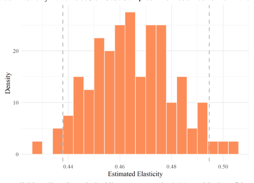

NOTE: figure/graphic rendered as an image from the PDF; its content is not machine-readable text. Caption (if any) follows as the next block.

WA-7

#### *C.2. Robustness Checks: Alternative time zone assumption for U.S. sample*

Although we have granular information regarding users' locations, we face challenges with the U.S.

sample due to the country's diverse time zones. Currently, we assume that every U.S. user resides in the

Eastern Time Zone, as this zone covers about 48% of the total population, followed by 29% in the Central

Time Zone, 6.7% in the Mountain Time Zone, and 16.6% in the Pacific Time Zone (RPS Relocation

2018). However, this assumption may not always be correct and may lead to the potential

misclassification of some users' time zones.

To ensure the robustness of our results and account for potential biases from such misclassification, we

implement a sensitivity analysis by assuming that **30%** of U.S. users reside in the Pacific Time Zone

(UTC-7). This proportion is twice the actual population share, providing a conservative adjustment to test

the impact of potential time zone misclassification.

We randomly select 30% of the U.S. sample, reassign these users to the Pacific Time Zone, and adjust the

relevant down dummy variable accordingly. We then re-estimate the first and second stage models. This

resampling procedure is repeated 100 times to ensure that our results are not driven by spurious patterns

in the data. Figure C1 below shows the distribution of the coefficient of interest from 100 replications.

Overall, we successfully replicate the positive effect. The empirical 95% confidence interval in grey

dashed lines do not include zero. This provides further assurance that potential misclassification of users'

time zones within the U.S. sample will not seriously distort our empirical findings.

Figure C1: Estimated Elasticity When 30% of U.S. Samples Are Assumed to Be in the Pacific Time Zone

Note: Color available online. Grey dashed lines represent the 95% empirical confidence interval.

Page 48

WA-8

#### *C.3. Robustness Checks: Alternative operationalizations of affected hours*

In the manuscript, we define the preferred gaming time within a day by identifying the top **eight** most

played gaming hours based on the calibration period data. However, these eight hours may either be too

few or too many to accurately capture an individual’s gaming preference. To ensure the robustness of our

findings, we replicate the main analyses using alternative definitions of prime gaming hours. Specifically,

we compute the top **six** and top **ten** most played gaming hours within a day and calculate the new affected

hours that overlap with Twitch’s server down events. We then re-estimate the first-stage model, obtain the

new control function, and replicate the second-stage model. The replicated second-stage results are

presented below.

Table C2: Robustness Checks Using Alternative Operationalizations of Affected Hours

| AffectedHours𝑖 (instrument)definedas: | Top sixhours | Top eight hours | Top tenhours |
| --- | --- | --- | --- |
| Model | (1) | (2) | (3) |
| ln(Viewmins𝑖𝑡ℎ + 1) | 320*** . | 304*** . | 296*** . |
| ln(Viewmins𝑖𝑡ℎ + 1) × 𝑳𝒐𝒚𝒂𝒍𝒕𝒚𝑖Firm−owned | (039) . 054** -. | (050) . 054*** -. | (056) . 054** -. |
| ln(Viewmins𝑖𝑡ℎ + 1) × 𝑳𝒐𝒚𝒂𝒍𝒕𝒚 𝑖Mega | (018) . 072*** -. | (016) . 072*** -. | (019) . 072*** -. |
| ln(Viewmins𝑖𝑡ℎ + 1) × 𝑳𝒐𝒚𝒂𝒍𝒕𝒚𝑖Micro | (008) . 175*** . | (009) . 175*** . | (007) . 175*** . |
|  | (019) . | (020) . | (017) . |
| Tenure𝑖𝑡 | 057 -. | 062 -. | 064 -. |
| 𝜔̂ (control function) 𝑖𝑡ℎ | (133) . 133*** -. | (136) . 118* -. | (156) . 109* -. |
|  | (039) . | (050) . | (055) . |
| IndividualuserFEs | Included | Included | Included |
| WeeklytimeFEs | Included | Included | Included |
| Three-hour block FEs | Included | Included | Included |
| Rsquared | 183 . | 183 . | 183 . |
| Rsquared(adj) . | 180 . | 180 . | 180 . |

NOTE: table converted from PDF layout to HTML text; cell boundaries are reconstructed. See PDF if exact alignment matters.

Page 49

WA-9

#### *C.4. Robustness Checks: Additional controls for unobservables*

We test the robustness of our findings by adding additional controls to address potential unobservable

factors. Table C3 reports the results of these robustness checks. First, we assume a linear time trend in

each country and replicate the second-stage moderation model by including a country-specific daily linear

time trend (model 1). Second, we replace the weekly fixed effects with daily fixed effects (model 2).

Finally, we include additional day-of-week fixed effects to account for specific temporal trends within

each day of the week. Across all robustness checks, we continue to observe results that are qualitatively

consistent with our main analyses.

Table C3: Robustness Checks—Additional Controls for Unobservables

| AdditionalControls | Country-level lineartimetrends | DailytimeFEs | Day-of -week FEs |
| --- | --- | --- | --- |
| Model | (1) | (2) | (3) |
| ln(Viewmins𝑖𝑡ℎ + 1) | 213*** . | 228*** . | 136* . |
| ln(Viewmins𝑖𝑡ℎ + 1) × 𝑳𝒐𝒚𝒂𝒍𝒕𝒚𝑖Firm−owned | (052) . -.055 ** | (053) . -.058** | (054) . -.058*** |
|  | (019) . | (018) . | (016) . |
| ln(Viewmins𝑖𝑡ℎ + 1) × 𝑳𝒐𝒚𝒂𝒍𝒕𝒚 𝑖Mega | -.071 *** | -.069*** | -.069*** |
| ln(Viewmins𝑖𝑡ℎ + 1) × 𝑳𝒐𝒚𝒂𝒍𝒕𝒚𝑖Micro | (008) . 175*** . | (009) . 175*** . | (008) . 176*** . |
| Tenure𝑖𝑡 | (021) . -.332 ** | (016) . -.359* | (019) . -.389** |
|  | (122) . | (141) . | (130) . |
| 𝜔̂ (control function) 𝑖𝑡ℎ | 027 -. | 042 -. | 050 . |
|  | (053) . | (053) . | (054) . |
| IndividualuserFEs | Included | Included | Included |
| TimeFEs | Includedas weeklytimeFEs | Includedas dailytimeFEs | Includedas weeklytimeFEs |
| Three-hour block FEs | Included | Included | Included |
| Additionalcontrols | Country-level Lineartimetrends |  | Day-of -week FEs |
| Rsquared | 183 . | 184 . | 183 . |
| Rsquared(adj) . | 180 . | 181 . | 180 . |

NOTE: table converted from PDF layout to HTML text; cell boundaries are reconstructed. See PDF if exact alignment matters.

FEs R squared .183 .184 .183 R squared (adj.) .180 .181 .180 Note: *p<.05; **p<.01; ***p<.001. The number of observations is 2,837,240. Bootstrapped standard errors with 50 resamples are used and are in parentheses. The moderators are all centered on their means.

Page 50

WA-10

#### *C.5. Robustness Checks: Replications with subsets of data*

Another set of analyses we perform is to replicate the analyses using subsets of data, with the results

reported in Table C4. First, we replicate the analyses using only the data from the week of the Twitch

interruption. This is because the variations created by the instruments are largely present during this time

frame. Thus, this ensures that our findings are not driven by data points without variations created by the

instruments (model 1). Second, since the focal game is a freemium game, there may be users who are

highly loyal to the game and others who rarely play during the period. To focus on users exhibiting

economically meaningful behaviors, we replicate the results using the top users who account for either

99% or 95% of total game time. These results are presented in models 2 and 3. We find that we are able to

replicate the core findings of our analyses using these subsets of data.

Table C4: Robustness Checks—Replications with Subsets of Data

| Subset | WeekofTwitch Interruption | Samples accountingfor 99%oftotalusage | Samples accountingfor 95%oftotalusage |
| --- | --- | --- | --- |
| Model | (1) | (2) | (3) |
| ln(Viewmins𝑖𝑡ℎ + 1) | 202*** . | 319*** . | 323*** . |
| ln(Viewmins𝑖𝑡ℎ + 1) × 𝑳𝒐𝒚𝒂𝒍𝒕𝒚𝑖Firm−owned | (049) . -.095 *** | (052) . -.058* | (065) . -.072** |
|  | (025) . | (023) . | (023) . |
| ln(Viewmins𝑖𝑡ℎ + 1) × 𝑳𝒐𝒚𝒂𝒍𝒕𝒚 𝑖Mega | -.075 *** | -.074*** | -.070*** |
| ln(Viewmins𝑖𝑡ℎ + 1) × 𝑳𝒐𝒚𝒂𝒍𝒕𝒚𝑖Micro | (012) . 150*** . | (009) . 181*** . | (010) . 190*** . |
|  | (025) . | (019) . | (022) . |
| Tenure𝑖𝑡 | 5250*** . | 118 -. | 165 -. |
|  | (652) . | (162) . | (157) . |
| 𝜔̂ (control function) 𝑖𝑡ℎ | 029 -. | -.121* | 114 -. |
|  | (049) . | (052) . | (066) . |
| IndividualuserFEs | Included | Included | Included |
| WeeklytimeFEs | Included | Included | Included |
| Three-hour block FEs | Included | Included | Included |
| Rsquared | 229 . | 176 . | 173 . |
| Rsquared(adj) . | 215 . | 173 . | 170 . |
| Observations | 567448 , | 2526160 , , | 2141720 , , |

NOTE: table converted from PDF layout to HTML text; cell boundaries are reconstructed. See PDF if exact alignment matters.

Observations 567,448 2,526,160 2,141,720 Note: *p<.05; **p<.01; ***p<.001. Bootstrapped standard errors with 50 resamples are used and are in parentheses. The moderators are all centered on their means.

Page 51

WA-11

#### *References for Web Appendix*

RPS Relocation (2018) American Cities by Time Zone. *RPS Relocation Blog*.